# SUMMARY

## 0 - IMPORT LIBRARIES AND FILES

## I - CORRECTION TEMPERATURE

## II - REMOVE SEASONALITY

#### 1) Autocorrelation

#### 2) Seasonality

#### 3) Stationarity

#### 4) Partial autocorrelation

## III - FORECAST CONSUMPTION

#### 1) Holt-Winters

#### 2) SARIMA

#### 3) Validation

# 0 - IMPORT LIBRARIES AND FILES

```python
import pandas as pd
import numpy as np
import matplotlib.pyplot as plt
import seaborn as sns
from datetime import datetime, timedelta
from dateutil.relativedelta import relativedelta
from math import sqrt

# Linear Regression
import statsmodels.api as sm
from sklearn import preprocessing

# Seasonality
from statsmodels.tsa.seasonal import seasonal_decompose

# Autocorrelation
from statsmodels.graphics import tsaplots

# Stationarity
from statsmodels.tsa.stattools import adfuller

# Holt-Winters
from statsmodels.tsa.holtwinters import ExponentialSmoothing as HWES

# SARIMA
import pmdarima as pm
from sklearn.metrics import mean_squared_error, mean_absolute_percentage_error

data = pd.read_csv('data_nettoye')
data.date = pd.to_datetime(data.date)
```

# I - CORRECTION TEMPERATURE

```python
# Linear Regression

X = data[["dju"]]
y = data["consumption"]

X_assign = X.assign(intercept = [1]*X.shape[0])

lr = sm.OLS(y, X_assign).fit()
print(lr.summary2())
```

```
                  Results: Ordinary least squares
===================================================================
Model:              OLS              Adj. R-squared:     0.925
Dependent Variable: consumption      AIC:                1998.1040
Date:               2022-01-14 12:20 BIC:                2003.5231
No. Observations:   111              Log-Likelihood:     -997.05
Df Model:           1                F-statistic:        1364.
Df Residuals:       109              Prob (F-statistic): 1.84e-63
R-squared:          0.926            Scale:              3.7799e+06
-------------------------------------------------------------------
             Coef.    Std.Err.    t    P>|t|    [0.025     0.975]
-------------------------------------------------------------------
dju           51.3424   1.3900 36.9383 0.0000    48.5876    54.0972
intercept  29951.2350 326.9003 91.6219 0.0000 29303.3292 30599.1407
-------------------------------------------------------------------
Omnibus:               3.156         Durbin-Watson:           1.565
Prob(Omnibus):         0.206         Jarque-Bera (JB):        2.570
Skew:                  -0.283        Prob(JB):                0.277
Kurtosis:              3.485         Condition No.:           417
===================================================================
```

```python
# Parameters
a, b = lr.params["dju"], lr.params["intercept"]
a, b
```

```
(51.34239735616836, 29951.234973794013)
```

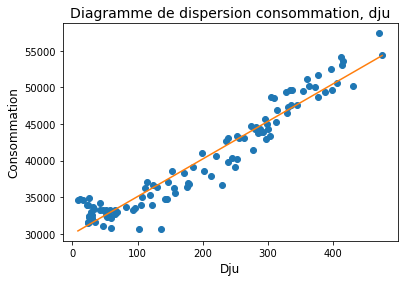

```python
# Plot LR
X = X_assign["dju"]

plt.plot(X,y,"o")
plt.plot(np.arange(min(X), max(X)), [a*x+b for x in np.arange(min(X), max(X))])
plt.title("Diagramme de dispersion consommation, dju", fontsize=14)
plt.xlabel("Dju", fontsize=12)
plt.ylabel("Consommation",  fontsize=12)
plt.savefig("images_soutenance/lr.jpeg", format="jpeg")
```

Il y a une corrélation très forte entre les DJU et la consommation.

```python
# New column with standardized consumption
data["cons_norm"] = (data['consumption']-(data["dju"]*a))
data
```

|  | date | dju | consumption | cons_norm |
| --- | --- | --- | --- | --- |
| 0 | 2012-01-01 | 359.5 | 51086 | 32628.408150 |
| 1 | 2012-02-01 | 475.6 | 54476 | 30057.555817 |
| 2 | 2012-03-01 | 238.7 | 43156 | 30900.569751 |
| 3 | 2012-04-01 | 252.4 | 40176 | 27217.178907 |
| 4 | 2012-05-01 | 118.4 | 35257 | 29178.060153 |
| ... | ... | ... | ... | ... |
| 106 | 2020-11-01 | 238.6 | 39840 | 27589.703991 |
| 107 | 2020-12-01 | 344.4 | 47565 | 29882.678351 |
| 108 | 2021-01-01 | 414.1 | 53006 | 31745.113255 |
| 109 | 2021-02-01 | 297.9 | 42979 | 27684.099828 |
| 110 | 2021-03-01 | 303.5 | 43341 | 27758.582402 |

111 rows × 4 columns

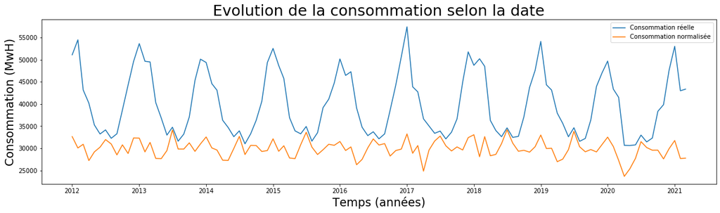

```python
# Plot
plt.figure(figsize=(20,5))
sns.lineplot(data = data, x="date", y="consumption")
sns.lineplot(data = data, x="date", y="cons_norm")
plt.title("Evolution de la consommation selon la date", fontsize="25")
plt.xlabel('Temps (années)', fontsize='19')
plt.ylabel('Consommation (MwH)', fontsize='19')
plt.legend(["Consommation réelle", "Consommation normalisée"])
plt.savefig("images_soutenance/correction_effet_temp.jpeg", format="jpeg")
```

# II - REMOVE SEASONALITY

```python
desaisonnalisation = data[["date", "cons_norm"]].set_index("date")
desaisonnalisation.head(3)
```

| date | cons_norm |
| --- | --- |
| 2012-01-01 | 32628.408150 |
| 2012-02-01 | 30057.555817 |
| 2012-03-01 | 30900.569751 |

##### Autocorrelation

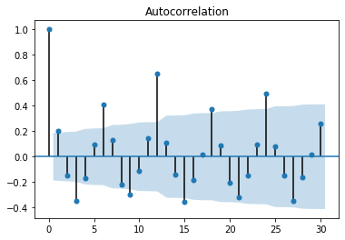

```python
fig = tsaplots.plot_acf(desaisonnalisation, lags=30)
plt.savefig("images_soutenance/acf.jpeg", format="jpeg")
plt.show()
```

J'observe une saisonnalité claire, prévisible, de 12 mois (c'est quand x=12 que le graphe est le plus autocorrélé).  
Il semble y avoir une saisonnalité à 3 et 6 mois aussi. Les pics à 12 mois étant très hauts, on les analyse tout de même en premier lieu.

##### Seasonality

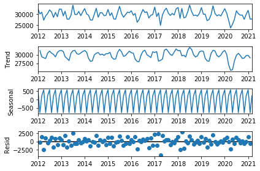

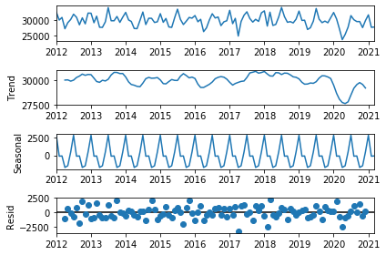

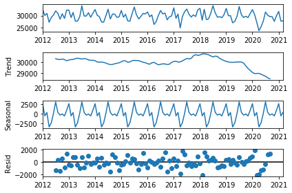

```python
seasonal_decompose(desaisonnalisation, model='additive', period=3).plot()
seasonal_decompose(desaisonnalisation, model='additive', period=6).plot()
seasonal_decompose(desaisonnalisation, model='additive', period=12).plot()
plt.savefig("images_soutenance/seasonal_decompose.jpeg", format="jpeg")
plt.show()
```

La saisonnalité est parfaite à 3 mois.  
Cependant, il est logique que la saisonnalité suive le cycle des saisons, sur toute l'année. Je désaisonnalise donc, dans un premier temps, sur 12 mois.

```python
# Trend with seasonal_decompose

trend = pd.DataFrame(seasonal_decompose(desaisonnalisation, model='additive',
                                        period=12).trend)

# Trend with rolling

trend['pandas_SMA_12'] = desaisonnalisation.iloc[:,0].rolling(window=12).mean()

trend.head(20)
```

| date | trend | pandas_SMA_12 |
| --- | --- | --- |
| 2012-01-01 | NaN | NaN |
| 2012-02-01 | NaN | NaN |
| 2012-03-01 | NaN | NaN |
| 2012-04-01 | NaN | NaN |
| 2012-05-01 | NaN | NaN |
| 2012-06-01 | NaN | NaN |
| 2012-07-01 | 30282.086860 | NaN |
| 2012-08-01 | 30231.011458 | NaN |
| 2012-09-01 | 30211.677662 | NaN |
| 2012-10-01 | 30249.184134 | NaN |
| 2012-11-01 | 30206.016933 | NaN |
| 2012-12-01 | 30110.757087 | 30296.558047 |
| 2013-01-01 | 30169.136938 | 30267.615673 |
| 2013-02-01 | 30212.144869 | 30194.407243 |
| 2013-03-01 | 30219.807148 | 30228.948081 |
| 2013-04-01 | 30293.348854 | 30269.420186 |
| 2013-05-01 | 30332.003910 | 30142.613680 |
| 2013-06-01 | 30296.291716 | 30078.900495 |
| 2013-07-01 | 30251.758690 | 30259.373382 |
| 2013-08-01 | 30300.305254 | 30164.916357 |

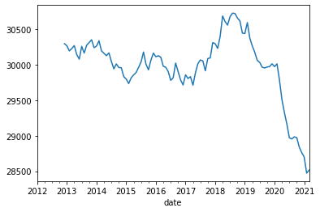

```python
trend.pandas_SMA_12.plot()
```

##### Stationarity

```python
# Dicky-Fuller

result = adfuller(trend['pandas_SMA_12'].dropna())

# Print the test statistic and the p-value
print('ADF Statistic:', result[0])
print('p-value:', result[1])
```

```
ADF Statistic: -1.116263614670267
p-value: 0.708542778627792
```

La pvalue est très supérieure à 5%, la série n'est donc pas stationnaire.

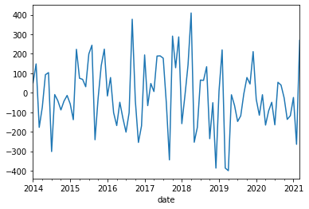

```python
# Make the series stationnary
data_stationnarise = trend['pandas_SMA_12'].diff().diff(12).dropna()

# Plot the time series
fig, ax = plt.subplots()
data_stationnarise.plot(ax=ax)
plt.show()
```

```python
result = adfuller(data_stationnarise)
print('ADF Statistic:', result[0])
print('p-value:', result[1])
```

```
ADF Statistic: -3.5072827698843305
p-value: 0.0078020151924282554
```

Après transformation, la p-value est très inférieure à 5% : la série est stationnaire.  
d = 1 et D = 1

##### Partial autocorrelation

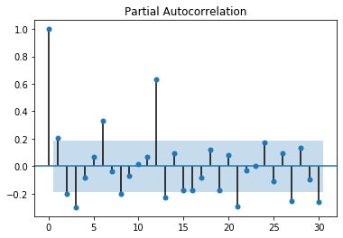

```python
# PACF

fig = tsaplots.plot_pacf(desaisonnalisation, lags=30)
plt.savefig("images_soutenance/pacf.jpeg", format="jpeg")
plt.show()
```

# III - FORECAST CONSUMPTION

##### Holt-Winters

```python
# HWES needs no seasonality

model_HWES = HWES(data_stationnarise, seasonal_periods=12, trend='add', seasonal='add')
fitted_HWES = model_HWES.fit()
forecast_HWES = fitted_HWES.forecast(steps=12)
```

```python
df_prediction_HWES = pd.DataFrame(forecast_HWES)
df_prediction_HWES.rename(columns={0:"consommation"}, inplace=True)
df_prediction_HWES.index.names = ["date"]
```

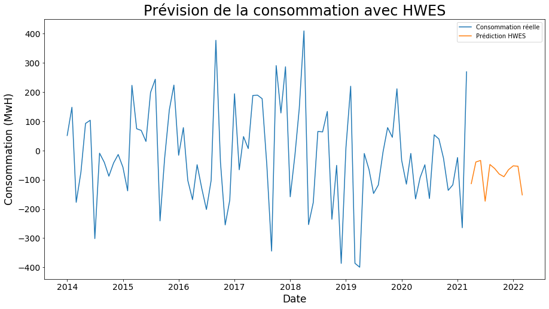

```python
# Plot HWES

fig = plt.figure()
plt.figure(figsize=(15,8))
plt.xlabel('Date', fontsize=17)
plt.ylabel('Consommation (MwH)', fontsize=17)
plt.xticks(fontsize=14)
plt.yticks(fontsize=14)
fig.suptitle('Prédiction de la consommation - modèle HWES')
conso_reelle = plt.plot(data_stationnarise, label='Consommation réelle')
charge_predite_hwes = plt.plot(forecast_HWES, label='Prédiction HWES')
plt.title("Prévision de la consommation avec HWES",fontsize=24)
plt.legend()
plt.savefig("images_soutenance/prediction_hwes.jpeg", format="jpeg")
plt.show()
```

##### SARIMA

SARIMA tient compte de la tendance et de la saisonnalité : on reprend les données avant stationnarisation et désaisonnalisation, mais avec l'effet température corrigé.

```python
data_sarima = data[["date", "cons_norm"]].set_index("date")

# Forecast 1 year

results_sarima_auto_1_an = pm.auto_arima(data_sarima, seasonal=True, m=12,d=1, D=1,
                                         start_p=0,
                                         start_q=0, max_p=2, max_q=2, max_P=2, max_Q=2,
                                         trace=True,
                                            error_action='ignore',suppress_warnings=True)

liste_forecast_sarima_auto_1_an = results_sarima_auto_1_an.predict(n_periods=12).tolist()

dernier_mois = data_sarima[-1:].index
dates_forecast = pd.date_range(dernier_mois[0]+relativedelta(months=1), freq='MS', periods=12).tolist()

forecast_sarima_auto_1_an = pd.DataFrame(index = dates_forecast)
forecast_sarima_auto_1_an["prediction"] = liste_forecast_sarima_auto_1_an
```

```
Performing stepwise search to minimize aic
 ARIMA(0,1,0)(1,1,1)[12]             : AIC=inf, Time=0.60 sec
 ARIMA(0,1,0)(0,1,0)[12]             : AIC=1740.033, Time=0.04 sec
 ARIMA(1,1,0)(1,1,0)[12]             : AIC=1730.953, Time=0.16 sec
 ARIMA(0,1,1)(0,1,1)[12]             : AIC=1725.836, Time=0.16 sec
 ARIMA(0,1,1)(0,1,0)[12]             : AIC=1733.734, Time=0.12 sec
 ARIMA(0,1,1)(1,1,1)[12]             : AIC=1719.701, Time=0.35 sec
 ARIMA(0,1,1)(1,1,0)[12]             : AIC=1728.762, Time=0.34 sec
 ARIMA(0,1,1)(2,1,1)[12]             : AIC=1720.402, Time=0.79 sec
 ARIMA(0,1,1)(1,1,2)[12]             : AIC=1716.809, Time=0.96 sec
 ARIMA(0,1,1)(0,1,2)[12]             : AIC=1717.981, Time=0.50 sec
 ARIMA(0,1,1)(2,1,2)[12]             : AIC=inf, Time=2.13 sec
 ARIMA(0,1,0)(1,1,2)[12]             : AIC=1719.666, Time=1.44 sec
 ARIMA(1,1,1)(1,1,2)[12]             : AIC=1717.066, Time=1.17 sec
 ARIMA(0,1,2)(1,1,2)[12]             : AIC=1715.648, Time=1.78 sec
 ARIMA(0,1,2)(0,1,2)[12]             : AIC=1716.640, Time=1.77 sec
 ARIMA(0,1,2)(1,1,1)[12]             : AIC=1718.793, Time=0.71 sec
 ARIMA(0,1,2)(2,1,2)[12]             : AIC=inf, Time=3.30 sec
 ARIMA(0,1,2)(0,1,1)[12]             : AIC=1725.966, Time=0.41 sec
 ARIMA(0,1,2)(2,1,1)[12]             : AIC=1719.025, Time=1.37 sec
 ARIMA(1,1,2)(1,1,2)[12]             : AIC=inf, Time=2.54 sec
 ARIMA(0,1,2)(1,1,2)[12] intercept   : AIC=1716.304, Time=2.47 sec

Best model:  ARIMA(0,1,2)(1,1,2)[12]
Total fit time: 23.113 seconds
```

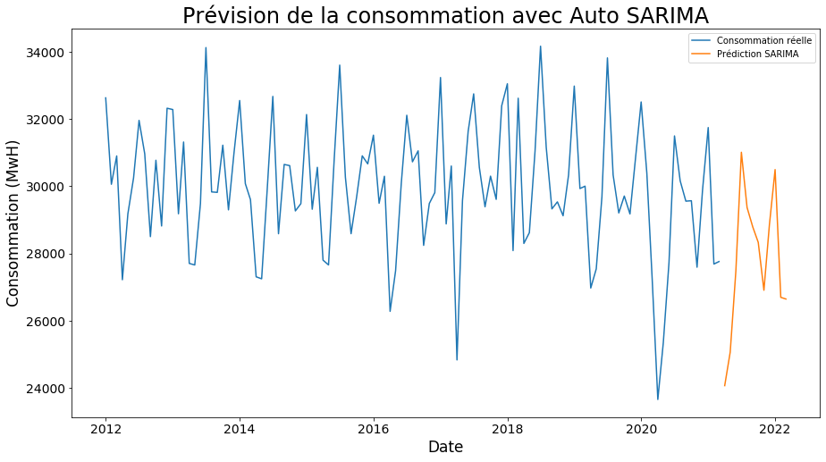

```python
# Plot
fig = plt.figure()
plt.figure(figsize=(15,8))
plt.xlabel('Date', fontsize=17)
plt.ylabel('Consommation (MwH)', fontsize=17)
plt.xticks(fontsize=14)
plt.yticks(fontsize=14)
fig.suptitle('Prédiction de la consommation - modèle SARIMA')
conso_reelle = plt.plot(data_sarima, label='Consommation réelle')
charge_predite_auto_sarima = plt.plot(forecast_sarima_auto_1_an,
                                                      label='Prédiction SARIMA')
plt.title("Prévision de la consommation avec Auto SARIMA",fontsize=24)
plt.legend()
plt.savefig("images_soutenance/prediction_sarima.jpeg", format="jpeg")
plt.show()
```

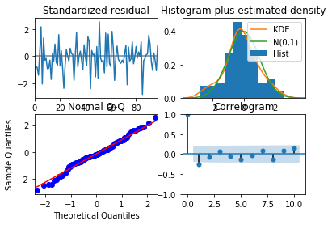

```python
results_sarima_auto_1_an.plot_diagnostics()
plt.show()
```

###### Validation

```python
# Make model HWES and SARIMA and check performance

nb_mois_test = 12

# Dataset HWES
nb_lignes_hwes = len(data_stationnarise)
data_hwes_train = data_stationnarise.iloc[:nb_lignes_hwes-nb_mois_test]
data_hwes_test = data_stationnarise.iloc[nb_lignes_hwes-nb_mois_test:]

# Model HWES
model_HWES = HWES(data_hwes_train, seasonal_periods=12, trend='add', seasonal='add')
fitted_HWES = model_HWES.fit()
forecast_HWES = fitted_HWES.forecast(steps=12)

df_prediction_HWES = pd.DataFrame(forecast_HWES)
df_prediction_HWES.rename(columns={0:"consommation"}, inplace=True)
df_prediction_HWES.index.names = ["date"]

# Dataset SARIMA
nb_lignes_sarima = len(data_sarima)
data_sarima_train = data_sarima.iloc[:nb_lignes_sarima-nb_mois_test]
data_sarima_test = data_sarima.iloc[nb_lignes_sarima-nb_mois_test:]

# Model SARIMA
results_sarima_auto_1_an = pm.auto_arima(data_sarima_train, seasonal=True, m=12,d=1, D=0,start_p=0,
                              start_q=0, max_p=2, max_q=2, max_P=2, max_Q=2,trace=True,
                                         error_action='ignore',suppress_warnings=True)

liste_forecast_sarima_auto_1_an = results_sarima_auto_1_an.predict(n_periods=12).tolist()

dernier_mois = data_sarima_train[-1:].index
dates_forecast = pd.date_range(dernier_mois[0]+relativedelta(months=1), freq='MS', periods=12).tolist()

forecast_sarima_auto_1_an = pd.DataFrame(index = dates_forecast)
forecast_sarima_auto_1_an["prediction"] = liste_forecast_sarima_auto_1_an
```

```
Performing stepwise search to minimize aic
 ARIMA(0,1,0)(1,0,1)[12] intercept   : AIC=inf, Time=0.45 sec
 ARIMA(0,1,0)(0,0,0)[12] intercept   : AIC=1809.819, Time=0.01 sec
 ARIMA(1,1,0)(1,0,0)[12] intercept   : AIC=1784.544, Time=0.22 sec
 ARIMA(0,1,1)(0,0,1)[12] intercept   : AIC=1789.062, Time=0.08 sec
 ARIMA(0,1,0)(0,0,0)[12]             : AIC=1807.874, Time=0.01 sec
 ARIMA(1,1,0)(0,0,0)[12] intercept   : AIC=1803.328, Time=0.02 sec
 ARIMA(1,1,0)(2,0,0)[12] intercept   : AIC=1783.732, Time=0.23 sec
 ARIMA(1,1,0)(2,0,1)[12] intercept   : AIC=1775.418, Time=1.33 sec
 ARIMA(1,1,0)(1,0,1)[12] intercept   : AIC=1764.729, Time=0.50 sec
 ARIMA(1,1,0)(0,0,1)[12] intercept   : AIC=1791.538, Time=0.07 sec
 ARIMA(1,1,0)(1,0,2)[12] intercept   : AIC=1774.334, Time=0.91 sec
 ARIMA(1,1,0)(0,0,2)[12] intercept   : AIC=1788.307, Time=0.17 sec
 ARIMA(1,1,0)(2,0,2)[12] intercept   : AIC=inf, Time=1.29 sec
 ARIMA(2,1,0)(1,0,1)[12] intercept   : AIC=inf, Time=0.61 sec
 ARIMA(1,1,1)(1,0,1)[12] intercept   : AIC=inf, Time=0.55 sec
 ARIMA(0,1,1)(1,0,1)[12] intercept   : AIC=1766.375, Time=0.49 sec
 ARIMA(2,1,1)(1,0,1)[12] intercept   : AIC=inf, Time=0.60 sec
 ARIMA(1,1,0)(1,0,1)[12]             : AIC=1763.478, Time=0.27 sec
 ARIMA(1,1,0)(0,0,1)[12]             : AIC=1789.577, Time=0.06 sec
 ARIMA(1,1,0)(1,0,0)[12]             : AIC=1782.673, Time=0.15 sec
 ARIMA(1,1,0)(2,0,1)[12]             : AIC=1765.443, Time=0.90 sec
 ARIMA(1,1,0)(1,0,2)[12]             : AIC=1765.439, Time=0.71 sec
 ARIMA(1,1,0)(0,0,0)[12]             : AIC=1801.312, Time=0.03 sec
 ARIMA(1,1,0)(0,0,2)[12]             : AIC=1786.373, Time=0.18 sec
 ARIMA(1,1,0)(2,0,0)[12]             : AIC=1781.870, Time=0.16 sec
 ARIMA(1,1,0)(2,0,2)[12]             : AIC=inf, Time=1.20 sec
 ARIMA(0,1,0)(1,0,1)[12]             : AIC=inf, Time=0.29 sec
 ARIMA(2,1,0)(1,0,1)[12]             : AIC=1764.655, Time=0.52 sec
 ARIMA(1,1,1)(1,0,1)[12]             : AIC=1761.886, Time=0.47 sec
 ARIMA(1,1,1)(0,0,1)[12]             : AIC=1783.263, Time=0.37 sec
 ARIMA(1,1,1)(1,0,0)[12]             : AIC=1778.787, Time=0.31 sec
 ARIMA(1,1,1)(2,0,1)[12]             : AIC=1763.861, Time=1.00 sec
 ARIMA(1,1,1)(1,0,2)[12]             : AIC=1763.859, Time=1.14 sec
 ARIMA(1,1,1)(0,0,0)[12]             : AIC=1794.450, Time=0.05 sec
 ARIMA(1,1,1)(0,0,2)[12]             : AIC=1781.522, Time=0.37 sec
 ARIMA(1,1,1)(2,0,0)[12]             : AIC=1777.287, Time=0.37 sec
 ARIMA(1,1,1)(2,0,2)[12]             : AIC=inf, Time=1.61 sec
 ARIMA(0,1,1)(1,0,1)[12]             : AIC=1762.484, Time=0.51 sec
 ARIMA(2,1,1)(1,0,1)[12]             : AIC=inf, Time=0.55 sec
 ARIMA(1,1,2)(1,0,1)[12]             : AIC=1763.886, Time=0.30 sec
 ARIMA(0,1,2)(1,0,1)[12]             : AIC=1763.058, Time=0.18 sec
 ARIMA(2,1,2)(1,0,1)[12]             : AIC=1765.321, Time=0.38 sec

Best model:  ARIMA(1,1,1)(1,0,1)[12]
Total fit time: 19.670 seconds
```

```python
# RMSE
rmse_sarima = sqrt(mean_squared_error(data_sarima_test, forecast_sarima_auto_1_an))
rmse_hwes = sqrt(mean_squared_error(data_hwes_test, df_prediction_HWES))

print("Score RMSE SARIMA : {:.2f}.".format(rmse_sarima))
print("Score RMSE Holt-Winters {:.2f}.".format(rmse_hwes))

# MAPE

mape_sarima = mean_absolute_percentage_error(data_sarima_test,
                                                 forecast_sarima_auto_1_an)
mape_hwes = mean_absolute_percentage_error(data_hwes_test,
                                                           df_prediction_HWES)

print("Score MAPE SARIMA : {:.2f}.".format(mape_sarima))
print("Score MAPE Holt-Winters {:.2f}.".format(mape_hwes))
```

```
Score RMSE SARIMA : 1374.51.
Score RMSE Holt-Winters 142.37.
Score MAPE SARIMA : 0.05.
Score MAPE Holt-Winters 1.17.
```

Le score MAPE est plus intéressant car les deux datasets utilisés ne sont pas les mêmes : celui de Holt-Winters étant stationnarisé, les valeurs sont bien plus faibles.  
On conclut que la modélisation la plus pertinente est SARIMA.